# Generating Comparitive Baselines for CAMVID with fastai’s Dynamic Unet

Published

September 19, 2020

> Exploring how baselines are being made and where fastai can fit in

This blog is also a Jupyter notebook available to run from the top down. There will be code snippets that you can then run in any environment. In this section I will be posting what version of `fastai` and `fastcore` I am currently running at the time of writing this:

- `fastai`: 2.0.13
- `fastcore`: 1.0.13

Note: this blog is the result of joint efforts between myself and [Juvian](https://forums.fast.ai/u/juvian/summary) on the forums

# CAMVID Benchmarks, Can’t We Just Use the Code from Class?

In the fastai course, we are walked through the [CAMVID](http://mi.eng.cam.ac.uk/research/projects/VideoRec/CamVid/) dataset, semantic segmentation with a car’s point of view. Ideally, we would then like to compare our results to the current [state-of-the-art benchmarks](https://paperswithcode.com/sota/semantic-segmentation-on-camvid).

However! In it’s current state, **this cannot be done**.

Why you might ask? Recently the benchmarks have been adapting a few “weird” changes, as well as making the dataset slightly easier, although comparing against them is not as straightforward as you would hope either (more on this at the end)

## The Metric:

First, the reported metrics are different. Instead of accuracy the Mean Intersection Over Union (mIOU) is reported, as well as individual IOU’s per class

## The Number of Classes:

In the original `fastai` version of the dataset, 31 classes are present, with an additional `void` classes that is ignored in the resulting benchmarks.

Researchers have since changed this class distribution to 11 total classes: Building, Tree, Sky, Car, Sign, Road, Pedestrian, Fence, Pole, Sidewalk, and Cyclist, with one more twelveth `void` class that is again, not taken into account.

This change in classes allows for a higher mIOU being reported without having the rarely-seen classes scew the results, so if you were running mIOU on the class notebooks and getting ~20% and being confused why it doesn’t align, this is why!

## The Splits

When we train with fastai, we wind up mixing in the baseline evaluation dataset with the training data! Not something we want at all! The `train`/`validation`/`test` split in most papers tends to be: `367`/`101`/`233`. That is correct, there is two-times as many test images as there are validation.

## The [SegNet](https://github.com/alexgkendall/SegNet-Tutorial) Version

This is a version that has images and labels coming in at a size of 360x480 pixels, which is half the size of what `fastai`’s source dataset is, but has its labels with the 11 classes. What is different paper to paper however is *how* they use the dataset, which can lead to issues. Let’s look at the current options and their pros/cons:

## Using the SegNet Dataset:

If we decide to use only this dataset, there is not much room for fastai’s tricks (such as progressive resizing and Pre-Sizing). That being said, there are [papers](https://paperswithcode.com/paper/template-based-automatic-search-of-compact) [which](https://paperswithcode.com/paper/template-based-automatic-search-of-compact) use this. If you look on the CAMVID leaderboard however, you’ll notice the best model placed at 8th. So what’s next?

## Well, what is the SOTA we’re comparing against then?

While below is a benchmark, we can’t truly compare against it. However, if we wish to, we will be focusing on the models that have an ImageNet backbone:

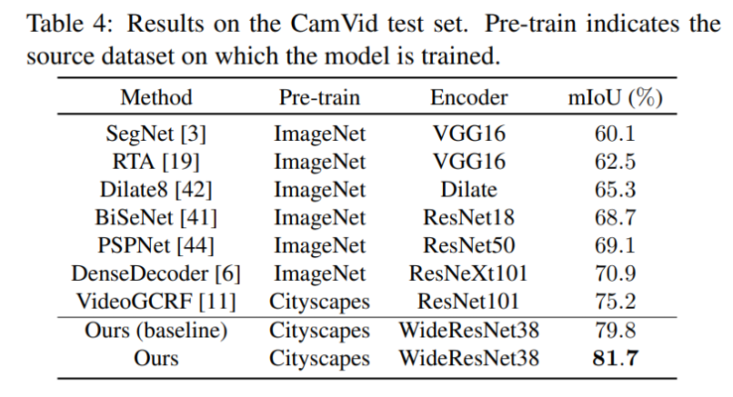

## Using the fastai Images with Smaller Labels

fastai uses the high-quality 720x960 images and labels, so it would make logical sense to train on them and use these smaller masks as the labels, which is being done on all the upper benchmarks.

### The Issue

There is a **very big** issue with this though, which Jeremy pointed out to us while we were discussing these new benchmark approaches. Simply upscaling the labels, without any adjustments to the fastai images, on its own sounds “weird.” Instead, what we do is resize the images back *down* to the 360x480 size before then upsampling them. This winds up increasing the final accuracy

# Can We Train Now?

Okay, enough talking, can we see some code to back up your claims?

Sure, let’s do it! To visualize what we will be doing, throughout this blog we will be:

1. Downloading a different dataset
2. Making a `DataBlock` which pre-sizes our images to the proper size
3. Making a `unet_learner` which:
- Uses a pretrained ResNet34 backbone
- Uses the `ranger` optimizer function
- Compare the use of `ReLU` and `Mish` in the head
- Uses both `IOU` and `mIOU` metrics to properly allow us to benchmark the results
4. Make a `test_dl` with the proper test set to evaluate with.

## Downloading the Dataset

The dataset currently lives in a the repository, so we will go ahead and clone it and make it our working directory:

```python
!git clone https://github.com/alexgkendall/SegNet-Tutorial.git
%cd SegNet-Tutorial/
```

Now we still want to use fastai’s input images, so we’ll go ahead and pull their CAMVID dataset. First let’s import fastai’s `vision` module:

```python
from fastai.vision.all import *
```

Then grab the data:

```python
path_i = untar_data(URLs.CAMVID)
```

Let’s see how both datasets are formatted:

```python
path_l = Path('')
```

```python
path_i.ls()
```

```python
path_l.ls()
```

```python
path_l = path_l/'CamVid'
```

```python
path_l.ls()
```

## DataBlock

As we saw how the data was split up, fastai currently doesn’t have something to work along those lines, the closest is `GrandparentSplitter`. We’ll write something similar called `FolderSplitter`, which can accept names for the train and validation folders:

```python
def _folder_idxs(items, name):
    def _inner(items, name): return mask2idxs(Path(o).parents[0].name == name for o in items)
    return [i for n in L(name) for i in _inner(items, n)]

def FolderSplitter(train_name='train', valid_name='valid'):
    "Split `items` from parent folder names `parent_idx` levels above the item"
    def _inner(o):
        return _folder_idxs(o, train_name),_folder_idxs(o, valid_name)
    return _inner
```

Next we will need a way to get our `x` images, since they live differently than our labels. We can use a custom function to do so:

```python
def get_x(o): return path_i/'images'/o.name
```

Finally we need a `get_y` that will use that same filename to go grab our working masks:

```python
def get_mask(o): return o.parent.parent/(o.parent.name + 'annot')/o.name
```

We have almost all the pieces to making our dataset now. We’ll use fastai’s progressive resizing when training, and pass in a set of codes for our dataset:

```python
codes = ['Sky', 'Building', 'Pole', 'Road', 'Pavement', 'Tree', 'SignSymbol', 'Fence', 'Car', 'Pedestrian', 'Bicyclist', 'Unlabelled']
half, full = (360, 480), (720, 960)
```

Now for those transforms. I mentioned earlier we will be downscaling and then upscaling the images, this way the same upscaling is applied to our labels and our images, though the images start from a higher quality. Since we want to train small, we’ll resize it back down in the batch transforms as well as normalize our inputs:

```python
item_tfms = [Resize(half), Resize(full)]
batch_tfms = [*aug_transforms(size=half), Normalize.from_stats(*imagenet_stats)]
```

And with this we can now build the `DataBlock` and `DataLoaders`:

```python
camvid = DataBlock(blocks=(ImageBlock, MaskBlock(codes=codes)),
                   get_items=get_image_files,
                   splitter=FolderSplitter(valid_name='val'),
                   get_x=get_x,
                   get_y=get_mask,
                   item_tfms=item_tfms,
                   batch_tfms=batch_tfms)
```

We’ll call the `.summary()` to make sure our images and masks do crop to the half size:

```python
camvid.summary(path_s)
```

```python
dls = camvid.dataloaders(path_l, bs=4)
```

Since we have a `void` column, our `c` attribute in the `DataLoaders` needs to be one less:

```python
dls.c = len(codes) - 1
```

## Metrics

For the next part Juvian was the one to bring this to life! We want class-wise `IOU` as well as `mIOU`, which are defined below:

```python
class IOU(AvgMetric):
    "Intersection over Union Metric"
    def __init__(self, class_index, class_label, axis, ignore_index=-1): store_attr('axis,class_index,class_label,ignore_index')
    def accumulate(self, learn):
        pred, targ = learn.pred.argmax(dim=self.axis), learn.y
        intersec = ((pred == targ) & (targ == self.class_index)).sum().item()
        union = (((pred == self.class_index) | (targ == self.class_index)) & (targ != self.ignore_index)).sum().item()
        if union: self.total += intersec
        self.count += union

    @property
    def name(self): return self.class_label
```

```python
from sklearn.metrics import confusion_matrix

class MIOU(AvgMetric):
    "Mean Intersection over Union Metric"
    def __init__(self, classes, axis): store_attr()

    def accumulate(self, learn):
        pred, targ = learn.pred.argmax(dim=self.axis).cpu(), learn.y.cpu()
        pred, targ = pred.flatten().numpy(), targ.flatten().numpy()
        self.total += confusion_matrix(targ, pred, range(0, self.classes))

    @property
    def value(self):
        conf_matrix = self.total
        per_class_TP = np.diagonal(conf_matrix).astype(float)
        per_class_FP = conf_matrix.sum(axis=0) - per_class_TP
        per_class_FN = conf_matrix.sum(axis=1) - per_class_TP
        iou_index = per_class_TP / (per_class_TP + per_class_FP + per_class_FN)
        iou_index = np.nan_to_num(iou_index)
        mean_iou_index = (np.mean(iou_index))

        return mean_iou_index

    @property
    def name(self): return 'miou'
```

With our metric functions defined, let’s combine them all. We’ll want a `mIOU`, as well as 11 `IOU` for each class:

```python
metrics = [MIOU(11, axis=1)]
```

> Note: we do not need to pass in an `ignore_index` here, as any values larger than 10 get ignored

And now let’s declare our `IOU`’s. Since there’s so many we’ll just make a function instead that relies on our `codes`:

```python
for x in range(11): metrics.append(IOU(x, codes[x], axis=1, ignore_index=11))
```

With this we can finally move over to our model and training:

## The Model and Training

For the model we will use a pretrained ResNet34 backbone architecture that has Mish on the head of the Dynamic Unet:

```python
config = unet_config(self_attention=False, act_cls=Mish)
```

Our optimizer will be `ranger`:

```python
opt_func = ranger
```

And finally, since we have an `ignore_index` we need to pass this into our loss function as well, otherwise we will trigger a `CUDA error: device-side assert triggered`

```python
loss_func = CrossEntropyLossFlat(ignore_index=11, axis=1)
```

Now let’s pass this all into `unet_learner`:

```python
learn = unet_learner(dls, resnet34, metrics=metrics, opt_func=opt_func,
                     loss_func=loss_func, config=config)
```

### Phase 1

We’ll find a good learning rate, fit for ten epochs frozen with `GradientAccumulation` to help with stability before unfreezing and training for a few more:

```python
learn.lr_find()
```

```python
lr = 2e-3
learn.fit_flat_cos(10, slice(lr), cbs=[GradientAccumulation(n_acc=16)])
```

```python
lrs = slice(lr/400, lr/4)
learn.unfreeze()
learn.fit_flat_cos(12, lrs, cbs=[GradientAccumulation(n_acc=16)])
```

We’ll save away this model and quickly check how it’s doing on our test set:

```python
learn.save("360")
```

```python
fnames = get_image_files(path_l/'test')
test_dl = learn.dls.test_dl(fnames, with_labels=True)
metrics = learn.validate(dl=test_dl)[1:]
names = list(map(lambda x: x.name, learn.metrics))
for value, metric in zip(metrics, names):
  print(metric, value)
```

[output not shown]

### Phase 2:

First let’s free up our memory:

```python
del learn
torch.cuda.empty_cache()
import gc
gc.collect()
```

We’ll adjust our transforms to instead keep our full sized images:

```python
item_tfms = [Resize(half), Resize(full)]
batch_tfms = [*aug_transforms(size=full), Normalize.from_stats(*imagenet_stats)]
```

And simply train again from there:

```python
camvid = DataBlock(blocks=(ImageBlock, MaskBlock(codes=codes)),
                   get_items=get_image_files,
                   splitter=FolderSplitter(valid_name='val'),
                   get_x=get_x,
                   get_y=get_mask,
                   item_tfms=item_tfms,
                   batch_tfms=batch_tfms)

dls = camvid.dataloaders(path_l, bs=2)
dls.c = len(codes) - 1
```

We’ll need to re-declare our metrics as the current ones have memory of our last training session:

```python
metrics = [MIOU(11, axis=1)]
for x in range(11): metrics.append(IOU(x, codes[x], axis=1, ignore_index=11))
```

And now let’s train:

```python
learn = unet_learner(dls, resnet34, metrics=metrics, opt_func=opt_func,
                     config=config, loss_func=loss_func)
learn.load('360');
```

```python
learn.freeze()

lr = 1e-3
learn.fine_tune(12, lr, cbs=[GradientAccumulation(n_acc=16), EarlyStoppingCallback()])
```

Let’s check it’s final IOU:

```python
fnames = get_image_files(path_l/'test')
test_dl = learn.dls.test_dl(fnames, with_labels=True)
metrics = learn.validate(dl=test_dl)[1:]
names = list(map(lambda x: x.name, learn.metrics))
for value, metric in zip(metrics, names):
  print(metric, value)
```

[output not shown]

## Results and Discussion

At first we tried a standard Unet without any special tricks, and we got a test mIOU of around 59%. From this baseline we tried applying Self-Attention, Label Smoothing, and the Mish activation function (as the default is ReLU).

What we found is that by simply applying Mish we could boost that 59% to around 64%, and do note that Mish was only applied to the head of the model, not in the ResNet backbone. (with the highest we got around 67% mIOU)

Self Attention did not seem to help as much, bringing down the mIOU to 62% when training even with the Mish activation function.

Applying Label Smoothing led to a very different result baked inside of each individual IOU. While the mIOU was not as high as a flat Mish model, the distributions of the IOU’s changed.

When applying the proper presizing techniques demonstrated here, we saw a boost of 10% mIOU, confirming an idea that simply blowing up your masks to match the original image resolution can diminish the value inside of them.

## Conclusions

What conclusions can we actually make from this study? Not as much as you would think, and the reason lies within current issues in Academia. Right now there are three different datasets being used:

- `fastai` images with `SegNet` masks
- `SegNet` images and masks
- `fastai` images and labels while ignoring all the other classes

Well… who is right then? Technically 2 and 3 are right, but the three cannot be compared equally. Remember that benchmark table I showed earlier? If you go and read the papers each use one of the three techniques done here.

So… what can we make of this?

There *is* one direct conclusion we can make: using `Mish` in the head of our Dynamic Unet boosts the mIOU by 5%. So it is absolutely worth trying and using with your projects.

## Where do we go from here?

A better dataset which is much more consistant is the [CityScapes](https://www.cityscapes-dataset.com/) dataset. It’s for research only and you must upload your predictions on the test set to the website, it’s essentially a Kaggle competition for researchers, a format I believe works much better. Researchers compare both how they perform on the validation set and the test set. This is certainly an easier benchmark for folks to tackle with the fastai UNet, so hopefully one day someone will try a benchmark and see how it does!